# Claim severity modeling with tree-based machine learning methods

Roel Henckaerts, Marie-Pier Côté, Katrien Antonio, and Roel Verbelen

May 2020

## Introduction

P&C insurers are interested in the total loss amount $L$ per unit of exposure-to-risk $e$, where $L$ is the total loss for the $N$ claims reported by a policyholder during the exposure period $e.$ They usually opt for a frequency-severity strategy to price a contract. Claim frequency $F$ is the number of claims $N$ filed per unit of exposure-to-risk $e.$ Claim severity $S$ refers to the cost per claim and is defined by the average amount per claim filed, that is the total loss amount $L$ divided by the number of claims $N.$ The technical price $\pi$ then follows as:

$$\begin{equation*}
\pi \, = \, \mathbb{E}\left(\frac{L}{e}\right) \, \overset{\mathrm{indep.}}{=} \, \mathbb{E}\left(\frac{N}{e}\right) \times \mathbb{E}\left(\frac{L}{N} \mid N > 0\right) \, = \, \mathbb{E}(F) \times \mathbb{E}(S),
\end{equation*}$$

assuming independence between the frequency and the severity component of the premium. An actuary develops a predictive model for both components in order to price a contract. Note that the model for severities is calibrated using only the data of policyholders that actually filed a claim (i.e., the observations with $N>0$).

This document is a supplementary material that accompanies our research paper (Henckaerts et al. 2020) on *Boosting insights in insurance tariff plans with tree-based machine learning*, available on [arXiv](https://arxiv.org/abs/1904.10890). In the paper, the results obtained with tree-based machine learning methods for claim frequencies are extensively discussed. This document provides the results for the claim severities regarding both model building and model interpretation.

## Model building

We start by illustrating how to develop a tree-based severity model with a particular focus on the loss function choice. In this analysis, we work with regression trees as these are the building blocks of all tree-based machine learning methods considered in (Henckaerts et al. 2020).

### Insurance data set

For a full description of the data, we refer to Section 4.1 of (Henckaerts et al. 2020) and Section 2 of (Henckaerts et al. 2018), but a snippet of the data is shown below:

```
##            id       expo claim nclaims      amount    average coverage ageph    sex bm power agec     fuel     use fleet postcode     long      lat
##     1:      1 1.00000000     1       1  1618.00104 1618.00104      TPL    50   male  5    77   12 gasoline private     0     1000 4.355223 50.84539
##     2:      5 0.04657534     1       1   155.97461  155.97461      TPL    28 female  9    70    7 gasoline private     0     1000 4.355223 50.84539
##     3:      7 1.00000000     1       1   155.97461  155.97461    TPL++    26   male 11    55    8 gasoline private     0     1000 4.355223 50.84539
##     4:     11 1.00000000     1       1   544.86997  544.86997    TPL++    39   male  1    85    2   diesel private     0     1000 4.355223 50.84539
##     5:     22 1.00000000     1       1   252.03335  252.03335      TPL    34   male  6   119    9 gasoline private     0     1000 4.355223 50.84539
##    ---
## 18272: 163151 1.00000000     1       1   545.91112  545.91112      TPL    50   male  0    40    7 gasoline private     0     9990 3.421256 51.19997
## 18273: 163170 0.81917808     1       1    78.90451   78.90451      TPL    49   male  4    65    3   diesel private     0     9990 3.421256 51.19997
## 18274: 163177 1.00000000     1       1   140.05984  140.05984      TPL    38   male  9    47    6   diesel private     0     9990 3.421256 51.19997
## 18275: 163206 1.00000000     1       1    62.09733   62.09733      TPL    25 female  6    55    2   diesel private     0     9990 3.421256 51.19997
## 18276: 163212 1.00000000     1       2 13818.22959 6909.11480    TPL++    24   male  6    47    2 gasoline private     0     9990 3.421256 51.19997
```

The goal is to model the average claim size (**average**) by making use of known characteristics such as the type of coverage (**coverage**) or the age of the policyholder (**ageph**).

### GAMs as a starting point

State-of-the-art insurance pricing models are typically developed within the framework of generalized additive models (GAMs) or generalized linear models (GLMs). A right-skewed and long-tailed distribution, such as the gamma or log-normal, is typically assumed for the response variable in the severity models. We build both a gamma and log-normal GAM as benchmark and we will compare these models with regression trees later on. We prefer the GAM above the GLM because the GAM can easily incorporate smooth effects of continuous risk factors. The selected variables in the models specified below follow from the analysis in (Henckaerts et al. 2020) for the gamma GAM and (Henckaerts et al. 2018) for the log-normal GAM.

```r
# Build a gamma GAM
gam_gamma <- gam(as.formula('average  ~  coverage + s(ageph) + s(agec)'), data = data, weights = nclaims, family = Gamma(link = 'log'))
# Build a log-normal GAM
gam_lnorm <- gam(as.formula('log(average)  ~  coverage + s(ageph) + s(bm)'), data = data, weights = nclaims, family = gaussian(link = 'identity'))
```

### Regression trees for severities

Machine learning methods require the specification of a loss function that is minimized during the training process. Inspired by the GAM framework and research on severity modeling, we explore two plausible options:

- using the gamma deviance
- using the Gaussian deviance after log-transforming the target variable.

The gamma and Gaussian deviance are defined as follows:

$$\begin{align*}
D_\text{gamma}\{y,f(\boldsymbol{x})\} & = 2 \ln \prod_{i=1}^{n} \frac{1}{y_i \Gamma(\alpha)} \left(\frac{\alpha y_i}{y_i}\right)^\alpha \exp\left(-\frac{\alpha y_i}{y_i}\right) - 2 \ln \prod_{i=1}^{n} \frac{1}{y_i \Gamma(\alpha)} \left\{\frac{\alpha y_i}{ f(\boldsymbol{x}_i)}\right\}^\alpha \exp\left\{-\frac{\alpha y_i}{ f(\boldsymbol{x}_i)}\right\} \\
& = 2 \sum_{i=1}^{n} \alpha \left\{ \frac{y_i - f(\boldsymbol{x}_i)}{f(\boldsymbol{x}_i)} - \ln \frac{y_i}{f(\boldsymbol{x}_i)} \right\} \\
\\
D_\text{Gauss}\{y,f(\boldsymbol{x})\} & = 2 \ln \prod_{i=1}^{n} \exp \left\{- \frac{1}{2\sigma^2}(y_i-y_i)^2\right\} - 2 \ln \prod_{i=1}^{n} \exp \left[- \frac{1}{2\sigma^2}\{y_i-f(\boldsymbol{x}_i)\}^2\right] \\
& = \frac{1}{\sigma^2} \sum_{i=1}^{n}\{y_i - f(\boldsymbol{x}_i)\}^2.
\end{align*}$$

For details on the discussion of these deviance measures, we refer to Section 3.2 of (Henckaerts et al. 2020). We extended the **rpart** package to be able to work with the gamma deviance because this is not implemented in the original package. The extended package, called **distRforest**, is available from [GitHub](https://github.com/henckr/distRforest). We use our extended version to build a regression tree for each of both loss functions considered:

```r
# Build a gamma tree
tree_gamma <-  distRforest::rpart(formula = as.formula('average ~ coverage + ageph + sex + bm + power + agec + fuel + use + fleet + long + lat'),
                                  data = data, method = 'gamma', weights = nclaims,
                                  control = rpart.control(cp = 2e-03, xval = 0, maxcompete = 0, maxsurrogate = 0, minbucket = 0.01*nrow(data)))
# Build a log-normal tree
tree_lnorm <-  distRforest::rpart(formula = as.formula('log(average) ~ coverage + ageph + sex + bm + power + agec + fuel + use + fleet + long + lat'),
                                  data = data, method = 'anova', weights = nclaims,
                                  control = rpart.control(cp = 2e-03, xval = 0, maxcompete = 0, maxsurrogate = 0, minbucket = 0.01*nrow(data)))
```

Below we show the resulting regression trees with the gamma variant on the left and the log-normal one on the right. Note that the severity trees are very small, as observed in Table 3 of (Henckaerts et al. 2020). This implies that, as expected, severity is very hard to predict and it is difficult to find relevant variables. Also note that the chosen variables correspond exactly to those that were present in the GAM specification for both gamma and log-normal.

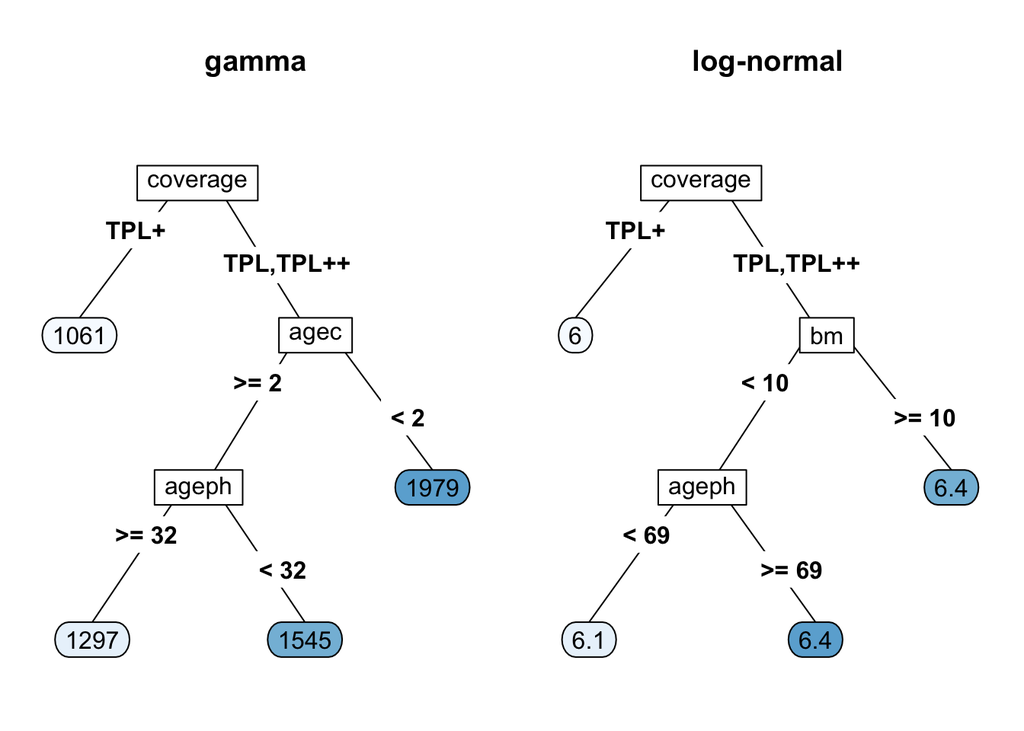

### Comparison of the methods

We now compare the predictions obtained with the four severity models: the gamma GAM, the log-normal GAM, the gamma tree and the log-normal tree. For the gamma GAM, we have the predictions of the mean readily available after applying the inverse link function to the additive predictor. Because the gamma tree is constructed for the original response, we immediately find the predictions for the mean response. For the log-normal GAM we know that we have to predict the mean of the distribution as $\exp(\mu + \sigma^2/2)$ where $\mu$ and $\sigma$ are the estimated mean and standard deviation on the log-scale. For the log-normal tree we do not have an estimate for $\sigma$ readily available as machine learning methods typically only put focus on an estimate for $\mu$. To circumvent this problem we use $\exp(\mu)$ as the prediction for the mean on the untransformed scale. Below we compare the average loss observed on the full data set with the average of the predictions obtained with the four models under investigation:

```
##    loss_amount gam_gamma gam_lnorm tree_gamma tree_lnorm
## 1:    1307.612  1306.647  1473.991   1307.303   471.2427
```

We observe that, on average, the predicted values for the gamma GAM and tree are almost exactly equal to the observed loss amounts. The log-normal GAM is slightly overestimating and the log-normal tree is heavily underestimating the amounts. The same conclusions can be drawn from the boxplots below with the observed average loss amount indicated by the horizontal line.

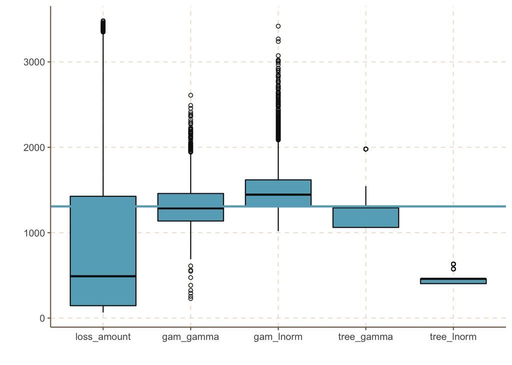

Ignoring the $\sigma^2/2$ term in the prediction for the log-normal tree has a big impact. Notice how close the predictions are to the median of the claim amounts (indicated with the black solid line in the leftmost boxplot). This comes as no surprise since the median of the lognormal distribution is obtained as $\exp(\mu)$. Another way of looking to this problem is by realizing that the prediction at a leaf node is produced as follows: $\exp(\frac{1}{n}\sum_{i=1}^n y_i)$ while it should be $\frac{1}{n}\sum_{i=1}^n\exp(y_i)$. This implies that the averaging in a node should be done after back-transforming instead of before.

### Solution for the log-normal tree

In the **distRforest** package, we provide a solution for training a tree with the log-normal deviance. Specifying `method = 'lognormal'` allows the tree to split on the log-scale but predict on the untransformed scale:

```r
# Build a new log-normal tree
tree_lnorm <-  distRforest::rpart(formula = as.formula('average ~ coverage + ageph + sex + bm + power + agec + fuel + use + fleet + long + lat'),
                                  data = data, method = 'lognormal', weights = nclaims,
                                  control = rpart.control(cp = 2e-03, xval = 0, maxcompete = 0, maxsurrogate = 0, minbucket = 0.01*nrow(data)))
```

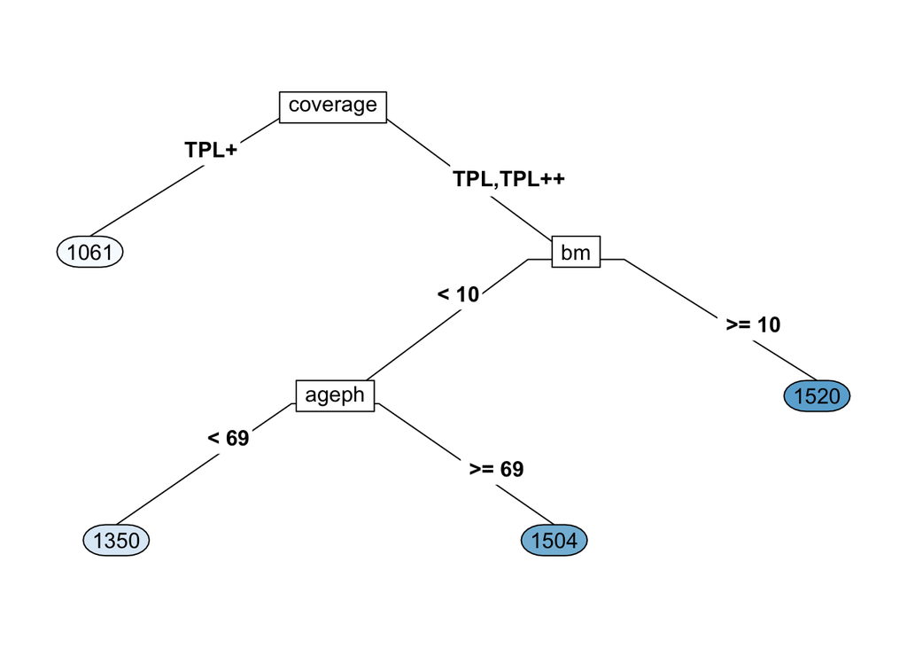

Note that the splits in the log-normal tree are exactly the same as before, but now the predictions are on the original scale. Notice how the average severity is estimated correctly after this adjustment:

```
##    loss_amount gam_gamma gam_lnorm tree_gamma tree_lnorm
## 1:    1307.612  1306.647  1473.991   1307.303   1307.505
```

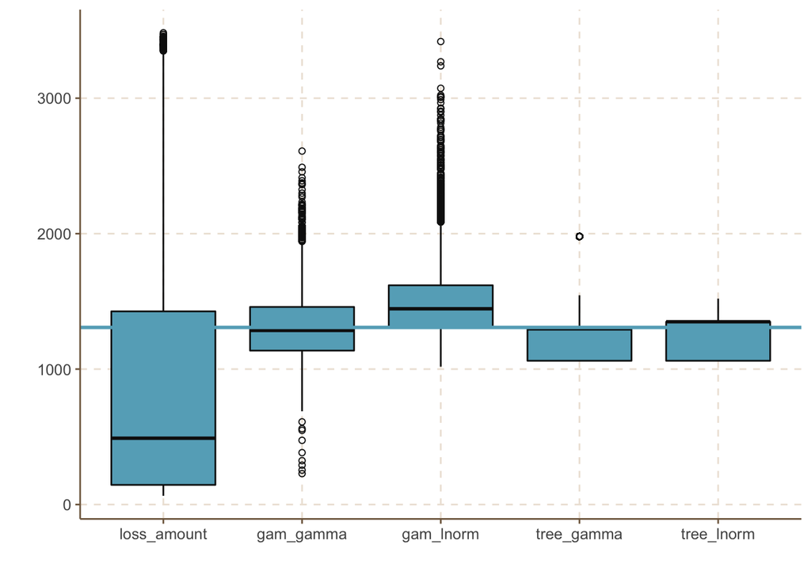

### Conclusions

Both the gamma and log-normal deviance as loss function in the regression tree are capable of modeling the average claim severity. From a machine learning perspective the gamma is however easier to work with since no transformations and back-transformations are needed in that case.

## Model interpretation

Section 4.3 of (Henckaerts et al. 2020) provides insights in the optimal frequency models in the form of partial dependence plots and individual conditional expectations. Here we will focus on similar insights for the optimal tree-based severity models constructed with gamma deviance as loss function. Figure 5 in (Henckaerts et al. 2020) teaches us that the most important variables for modeling claim severity are the following: the type of coverage, the age of the car, the age of the policyholder and the spatial information (longitude and latitude coordinates of the municipality of residence).

### Type of coverage

All tree-based methods agree that the limited material damage cover (TPL+) is the least risky for severities. The random forests and gradient boosting machines predict that policyholders with the comprehensive material damage cover (TPL++) are the most risky ones. The regression tree predicts the same risk level for TPL and TPL++ coverages.

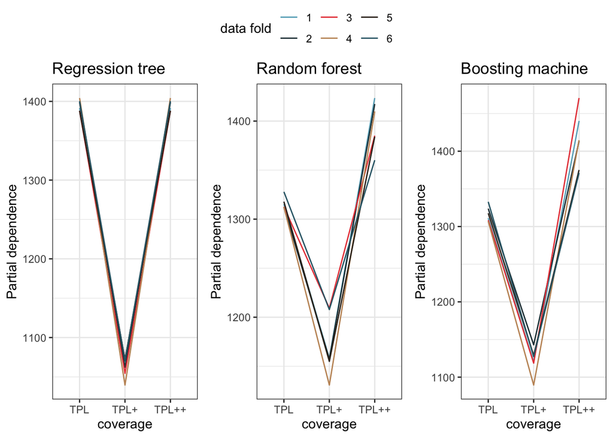

### Age of the car

The random forests and gradient boosting machines find that middle aged cars are posing the lowest risk for claim severity. New and vintage cars show an increase in risk, but the size of the increase depends on the data fold in question. The regression tree uses the age of the car as a split criterion in only two out of six cases, where it predicts an increased risk for new cars. There is no increased risk for vintage cars in the regression tree.

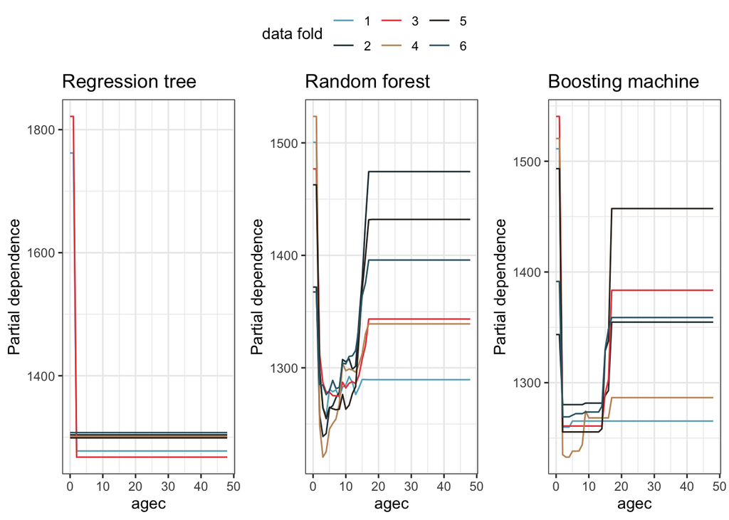

### Age of the policyholder

The random forests and gradient boosting machines predict that middle aged policyholders are less risky with respect to claim severity. There is an increase visible for younger and older policyholders, with the size of the increase again depending on the data fold considered. None of the six regression trees uses the age of the policyholders as a split variable such that each tree predicts the same severity for all ages.

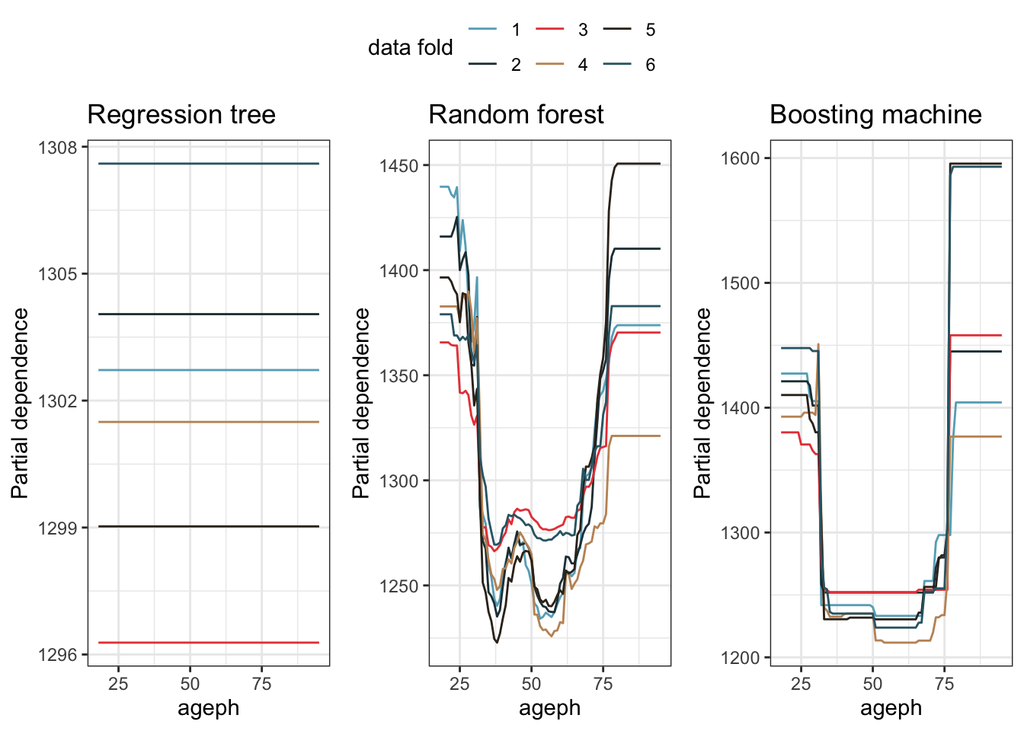

### Spatial information

The maps of Belgium below show the spatial partial dependence effect for the tree-based machine learning methods on data fold 3. The regression tree does not use spatial information and therefore predicts the same average severity for each municipality. The random forest and gradient boosting machine identify the West region of Belgium as the most risky area, followed by the South and North regions.

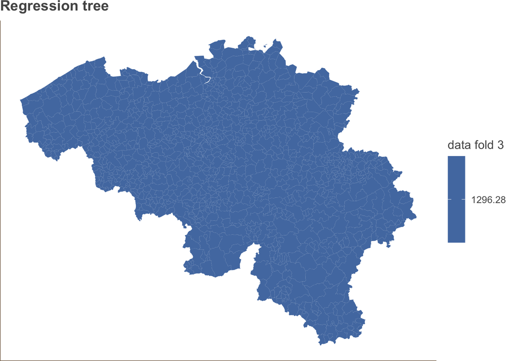

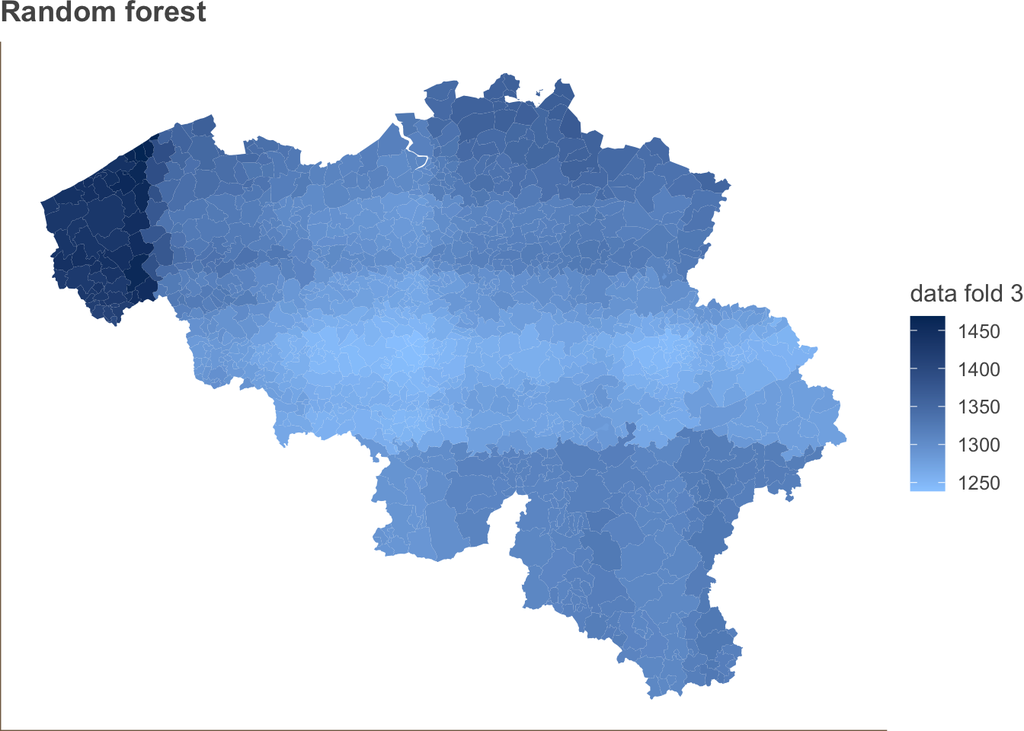

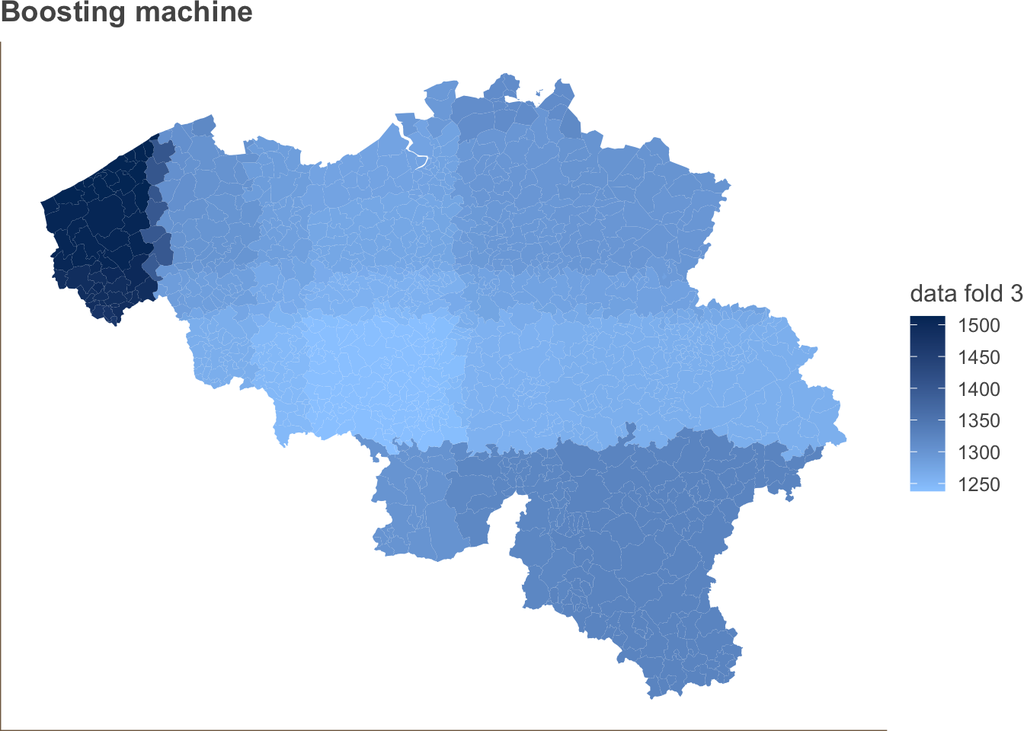

### Interactions at play

Five out of six optimal gradient boosting machines have a tree depth equal to one, see Table 1 in (Henckaerts et al. 2020). Therefore, these models do not incorporate interaction effects by definition. The optimal gradient boosting machine developed in data fold 4 has a tree depth of two however. Using Friedman’s $H$-statistic we were able to find one interesting interaction effect, namely the interaction between the power of the car and the type of coverage. The predicted severity for high-powered cars rises much higher for the TPL++ coverage compared to the two other types of coverages. This makes sense, assuming that high-powered cars are typically also more expensive cars. The comprehensive material damage cover (TPL++) will result in higher claim amounts for these more expensive cars as the (partial) value of those cars needs to be paid out.

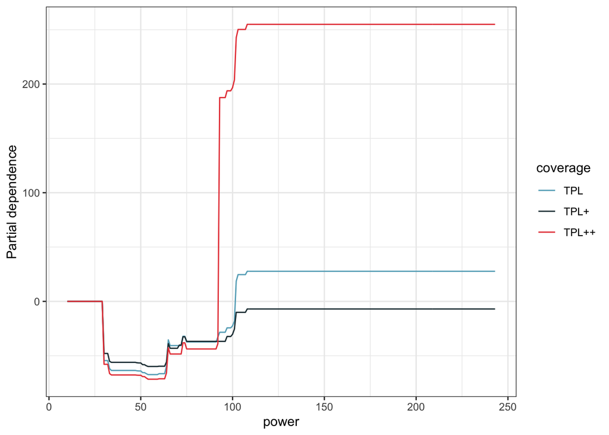

### Conclusions

Using the model interpretation tools proposed in Section 3.4 of (Henckaerts et al. 2020), we are able to gain some insights in the optimal severity models. Compared to claim frequency, less interesting effects and interactions are found as it remains a hard task to model and explain the expected claim severity.

## References

Henckaerts, R., K. Antonio, M. Clijsters, and R. Verbelen. 2018. “A Data Driven Binning Strategy for the Construction of Insurance Tariff Classes.” *Scandinavian Actuarial Journal* 2018 (8): 681–705. https://www.tandfonline.com/doi/full/10.1080/03461238.2018.1429300.

Henckaerts, R., M.P. Côté, K. Antonio, and R. Verbelen. 2020. “Boosting Insights in Insurance Tariff Plans with Tree-Based Machine Learning Methods.” *North American Actuarial Journal*. https://arxiv.org/abs/1904.10890.